# USING ART ANOVA, MULTIPLE REGRESSION, AND MONTE CARLO SIMULATION TO SELECT THE USAGE OF PROJECT MANAGEMENT METHODOLOGIES: WATERFALL, AGILE, AND SCRUM

Tu Tran Tran

November 3rd, 2025

# **INTRODUCTION**

This research aims to explain how Waterfall, Agile, and Scrum methodologies work in project management, and explore how Monte Carlo Simulation can help to select the correct method. Even though there have been multiple case studies of how each method can bring great results in certain conditions and vice versa, it is uncertain that the progress of a project will not be affected by scope creeps or the number of change requests. By understanding the importance of using the correct method, Project Managers can lead their team successfully throughout the whole project with excellent deliverables.

The research will be based on the following questions:

1. Which project management methodology (Waterfall, Agile, or Scrum) leads to the highest project success rating across varying project conditions?
2. After controlling for risk, cost overrun, and schedule variance, does methodology still have a meaningful impact on project success?
3. Under uncertainty, what is the probability that each methodology achieves high success (e.g., >80), and which methodology has the lowest downside risk?

# **1. DATASET OVERVIEW**

## **1.1. Data Generation Methodology**

This study utilizes a synthetic project portfolio dataset consisting of **1,000 project observations**.

The dataset was constructed algorithmically using simulated probability distributions to mimic realistic patterns and causal mechanisms commonly observed in software and IT project environments.

## **1.2. Variable Design Logic**

The dataset contains three major variable types:

| Layer | Variable Types | Purpose |
| --- | --- | --- |
| Classification Layer | methodology, complexity_level | define project category |
| Uncertainty Calibration Layer | risk_score, budget_overrun_pct, schedule_variance_days, technical_debt_index, etc. | simulate operational variation |
| Outcome Layer | success_rating, client_satisfaction, ROI_pct | define project performance |

In this dataset, the risk_score variable represents the project’s overall risk exposure on a normalized scale from 0 to 1. It was not generated randomly across all projects but rather through a structured, logic-based approach that reflects how risk naturally depends on project complexity.

Specifically, risk values were drawn from bounded uniform distributions that vary by complexity level:

| Complexity Level | Distribution Used for risk_score |
| --- | --- |
| Low | Uniform(0.20 – 0.50) |
| Medium | Uniform(0.40 – 0.70) |
| High | Uniform(0.60 – 0.90) |

This approach reflects established project management theory, where higher complexity is associated with greater uncertainty and a higher likelihood of emerging risks. In practice, risk levels do not fluctuate randomly across unrelated projects but are fundamentally linked to the inherent characteristics of the project. Stratifying risk by complexity therefore produces more realistic variation and allows the dataset to reflect the clustering patterns commonly observed in real-world IT project environments.

## **1.3. Distributional Assumptions**

Each continuous variable was drawn from a probability distribution grounded in domain reality:

| Variable | Distribution Applied | Rationale |
| --- | --- | --- |
| budget_estimate_millionUSD | Triangular(2,5,10) | realistic bounded cost estimates |
| budget_overrun_pct | Normal (mean varies by methodology) | Waterfall projects typically have higher overruns |
| schedule_variance_days | Normal (mean varies by methodology) | Waterfall tends to delay more than Agile/Scrum |
| risk_score | Uniform (range depends on complexity) | high complexity → higher risk ranges |
| stakeholder_alignment | Normal(μ=4,σ=0.6) | based on 1–5 Likert distribution |
| technical_debt_index | Uniform(0–1) | debt accumulates as a bounded ratio |

## **1.4. Structural Causality Model for Success**

Crucially, **success_rating is not random noise**.  
It is generated using a deterministic causal formula which encodes domain theory:

```
success_rating = 100
                     - (risk_score * 40)
                     - (budget_overrun_pct * 0.5)
                     - (schedule_variance_days / 10)
                     + (communication_efficiency * 5)
                     + (stakeholder_alignment * 2)
                     - (technical_debt_index * 10)
```

This reflects established project management research that:

- risk is the strongest negative driver of project success
- cost & schedule performance reduce success
- communication quality and stakeholder alignment increase success
- technical debt destroys future performance

| Variable Name | Measurement Unit / Scale | Variable Type |
| --- | --- | --- |
| `project_id` | integer identifier | identifier |
| `methodology` | categorical (Waterfall / Agile / Scrum) | categorical |
| `complexity_level` | categorical (Low / Medium / High) | categorical |
| `budget_estimate_millionUSD` | millions of USD | continuous numeric |
| `budget_overrun_pct` | percentage (%) | continuous numeric |
| `schedule_variance_days` | number of days | continuous numeric |
| `scope_changes` | count of change requests | discrete count |
| `team_size` | number of team members | discrete count |
| `risk_score` | normalized index 0–1 | numeric index |
| `communication_efficiency` | normalized index 0–1 | numeric index |
| `stakeholder_alignment` | Likert scale 1–5 | ordinal Likert |
| `iteration_count` | number of iterations / sprints | discrete count |
| `technical_debt_index` | normalized index 0–1 | numeric index |
| `success_rating` | 0–100 continuous score | continuous numeric |
| `client_satisfaction` | Likert scale 1–5 | ordinal Likert |
| `ROI_pct` | percentage (%) | continuous numeric |

# **2. PREPARATION**

## **2.1. Import data**

```r
project_portfolio <- read.csv("project_portfolio_dataset_expanded_1000.csv")
View(project_portfolio)
```

## **2.2. Define variables**

```r
project_portfolio$methodology <- factor(project_portfolio$methodology, levels=c("Waterfall","Agile","Scrum"))
project_portfolio$complexity_level <- factor(project_portfolio$complexity_level, levels=c("High","Medium","Low"))
```

## **2.3. Required Libraries**

```r
library(dplyr)
library(ggplot2)
library(nortest)
library(car)
library(ARTool)
library(gt)
library(MASS)
library(cowplot)
library(matrixcalc)
library(Matrix)
library(tidyr)
library(tibble)
```

# **3. ANOVA ANALYSIS METHODOLOGY**

## **3.1. Select the required variables for the analysis**

```r
project_portfolio <- project_portfolio %>%
  dplyr::select(success_rating, methodology, complexity_level)
View(project_portfolio)
```

## **3.2. Test ANOVA assumptions**

There are 4 variables requirements for ANOVA analysis:

a. The samples are independent: methodology, complexity_level

b. The dependent variable is a continuous variable (success_rating)

c. Normality: The dependent variables should be approximately normally distributed within each group

d. Homogeneity of variance

### **3.2.1. Using Shapiro-Wilk Test for residuals normality**

- H₀ (null hypothesis): Residuals follow a normal distribution.
- H₁ (alternative hypothesis): Residuals do not follow a normal distribution.

If p-value < 0.05, we reject H₀, indicating that the residuals deviate from normality.

```r
anova_residuals <- rstandard(aov(success_rating~methodology*complexity_level, data = project_portfolio))

shapiro.test(anova_residuals)
```

```
##
##  Shapiro-Wilk normality test
##
## data:  anova_residuals
## W = 0.99555, p-value = 0.005301
```

With p = 0.0053 < 0.05, there is statistical evidence that the residuals are not perfectly normal.

### **3.2.2. Using qqplot and bell-curve histogram to visualize the residuals normality**

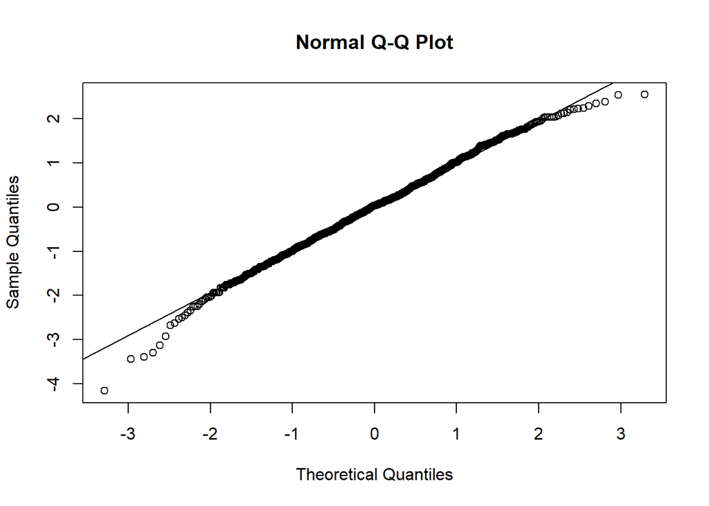

```r
## qqplot
qqnorm(anova_residuals)
qqline(anova_residuals)
```

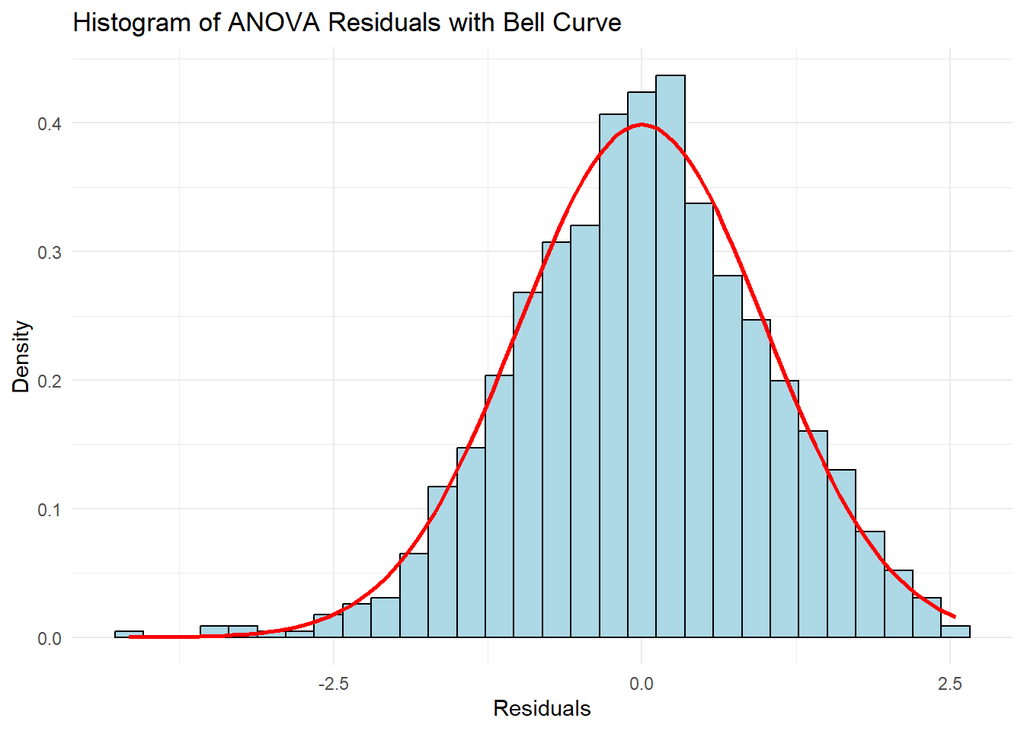

```r
## histogram + overlay bell-curve
df_residuals <- data.frame(residuals = anova_residuals)
mean_res <- mean(df_residuals$residuals)
sd_res <- sd(df_residuals$residuals)

ggplot(df_residuals, aes(x = residuals)) +
          geom_histogram(aes(y = after_stat(density)), bins = 30, fill = "lightblue", color = "black") +
          stat_function(fun = dnorm, args = list(mean = mean_res, sd = sd_res),
                        color = "red", linewidth = 1) +
          labs(title = "Histogram of ANOVA Residuals with Bell Curve",
               x = "Residuals", y = "Density") +
          theme_minimal()
```

Although the Shapiro-Wilk test returned a p-value of 0.005301 (indicating statistical deviation from normality),with a sample size of 1000, the test’s sensitivity may exaggerate minor deviations. The Q-Q plot and histogram (bell-curve) confirms that the deviation from normality is very slight and not practically concerning.

### **3.2.3. Using Levene Test for homogeneity of variance**

- H₀ (null hypothesis): The groups have equal variances.
- H₁ (alternative hypothesis): At least one group has a different variance.

```r
leveneTest(success_rating~methodology*complexity_level, data = project_portfolio)
```

```
## Levene's Test for Homogeneity of Variance (center = median)
##        Df F value    Pr(>F)
## group   8  9.4139 1.356e-12 ***
##       991
## ---
## Signif. codes:  0 '***' 0.001 '**' 0.01 '*' 0.05 '.' 0.1 ' ' 1
```

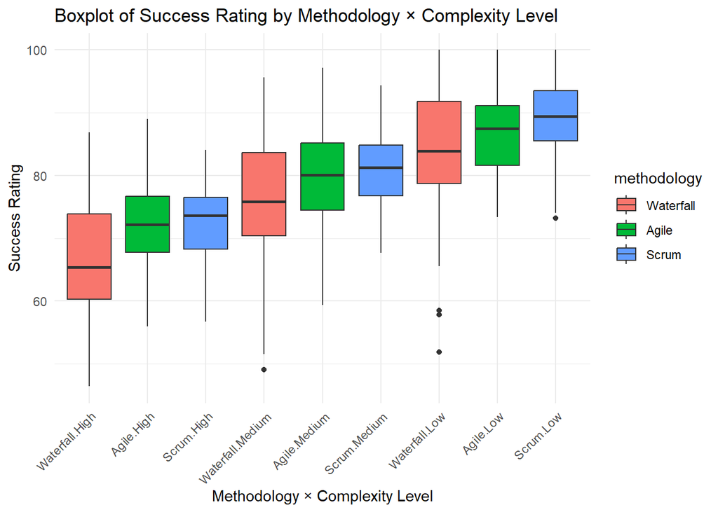

```r
ggplot(project_portfolio, aes(x = interaction(methodology, complexity_level),
                              y = success_rating,
                              fill = methodology)) +
    geom_boxplot() +
    labs(title = "Boxplot of Success Rating by Methodology × Complexity Level",
       x = "Methodology × Complexity Level",
       y = "Success Rating") +
    theme_minimal() +
    theme(axis.text.x = element_text(angle = 45, hjust = 1))
```

With a p-value ≈ 0.000000000001356, we strongly reject H₀. Since the assumption of homogeneity of variance is violated, which affects the reliability of F-tests in classical ANOVA, using Aligned Rank Transform ANOVA (ART) would be better instead of the classic ANOVA Test. That is because ART ANOVA does not require assumptions of normal distribution or homogeneity of variance.

## **3.3. Aligned Rank Transform ANOVA (ART)**

```r
art_model <- art(success_rating~methodology*complexity_level, data = project_portfolio)
  art_anova_result <- anova(art_model)

  View(art_anova_result)

## install.packages("gt") to visualize the result table

  art_anova_result %>%
    gt() %>%
    tab_header(title = "ART ANOVA Results") %>%
    fmt_number(columns = c(`F value`, `Pr(>F)`), decimals = 4)
```

ART ANOVA Results

| Term | Df | Df.res | Sum Sq | Sum Sq.res | F value | Pr(>F) |
| --- | --- | --- | --- | --- | --- | --- |
| methodology | 2 | 991 | 4507533.9 | 78817736 | 28.3373 | 0.0000 |
| complexity_level | 2 | 991 | 35844578.2 | 47342784 | 375.1572 | 0.0000 |
| methodology:complexity_level | 4 | 991 | 228833.6 | 83033483 | 0.6828 | 0.6040 |

The two-way nonparametric ART ANOVA results show that both project management methodology and project complexity level have statistically significant main effects on project success. Methodology has a significant effect on success_rating, F(2,991) = 28.34, p<.001, and complexity level has an even stronger effect, F(2,991) = 375.16, p<.001. In contrast, the interaction between methodology and complexity level is not significant, F(4,991) = 0.68, p = .604, indicating that the relative advantage of one methodology over another does not systematically change across different complexity levels. In practical terms, methodology and complexity each matter for success, but their effects appear to be additive rather than interactive.

# **4. Multiple Regression**

## **4.1. Model 1**

In this linear regression model, the dependent variable is “success_rating” and the categorical predictors are “methodology” and “complexity_level”, in which:

```r
lm_project_portfolio <- read.csv("project_portfolio_dataset_expanded_1000.csv")

model_1 <- lm(success_rating ~ methodology + complexity_level, data = lm_project_portfolio)

summary(model_1)
```

```
##
## Call:
## lm(formula = success_rating ~ methodology + complexity_level,
##     data = lm_project_portfolio)
##
## Residuals:
##     Min      1Q  Median      3Q     Max
## -31.943  -5.110   0.189   5.265  19.726
##
## Coefficients:
##                        Estimate Std. Error t value Pr(>|t|)
## (Intercept)             71.3868     0.5500 129.787  < 2e-16 ***
## methodologyScrum         1.3274     0.6105   2.174   0.0299 *
## methodologyWaterfall    -3.8066     0.5966  -6.381 2.69e-10 ***
## complexity_levelLow     16.2130     0.6095  26.602  < 2e-16 ***
## complexity_levelMedium   8.3236     0.6085  13.679  < 2e-16 ***
## ---
## Signif. codes:  0 '***' 0.001 '**' 0.01 '*' 0.05 '.' 0.1 ' ' 1
##
## Residual standard error: 7.799 on 995 degrees of freedom
## Multiple R-squared:  0.4378, Adjusted R-squared:  0.4355
## F-statistic: 193.7 on 4 and 995 DF,  p-value: < 2.2e-16
```

## **4.2. Model 2**

```r
model_2 <- lm(success_rating ~ methodology + complexity_level + risk_score + budget_overrun_pct + schedule_variance_days, data = lm_project_portfolio)

summary(model_2)
```

```
##
## Call:
## lm(formula = success_rating ~ methodology + complexity_level +
##     risk_score + budget_overrun_pct + schedule_variance_days,
##     data = lm_project_portfolio)
##
## Residuals:
##     Min      1Q  Median      3Q     Max
## -8.3707 -2.4582 -0.0639  2.5286  7.4690
##
## Coefficients:
##                          Estimate Std. Error t value Pr(>|t|)
## (Intercept)            104.880122   0.916072 114.489   <2e-16 ***
## methodologyScrum        -0.124504   0.251975  -0.494   0.6213
## methodologyWaterfall    -0.039019   0.268556  -0.145   0.8845
## complexity_levelLow      1.033341   0.539024   1.917   0.0555 .
## complexity_levelMedium   0.609358   0.347098   1.756   0.0795 .
## risk_score             -37.545922   1.171254 -32.056   <2e-16 ***
## budget_overrun_pct      -0.494690   0.008611 -57.452   <2e-16 ***
## schedule_variance_days  -0.094419   0.005707 -16.546   <2e-16 ***
## ---
## Signif. codes:  0 '***' 0.001 '**' 0.01 '*' 0.05 '.' 0.1 ' ' 1
##
## Residual standard error: 3.191 on 992 degrees of freedom
## Multiple R-squared:  0.9062, Adjusted R-squared:  0.9055
## F-statistic:  1369 on 7 and 992 DF,  p-value: < 2.2e-16
```

The full regression model, which adds risk_score, budget_overrun_pct, and schedule_variance_days to methodology and complexity, has very high explanatory power, accounting for about 90.6% of the variance in success_rating (Adj R²= 0.9055) and is highly significant overall (F(7,992)=1369, p<.001).

| Term | Estimate | p-value | Interpretation |
| --- | --- | --- | --- |
| methodologyAgile | +0.04 | 0.8845 | Not significant |
| methodologyScrum | -0.09 | 0.7665 | Not significant |
| complexity_levelMedium | +0.61 | 0.0795 | marginal (not strong) |
| complexity_levelLow | +1.03 | 0.0555 | borderline |

| Predictor | Estimate | p-value | Meaning |
| --- | --- | --- | --- |
| risk_score | −37.55 | <.001 | Higher risk score strongly reduces success rating |
| budget_overrun_pct | −0.495 | <.001 | Every extra % budget overrun reduces success ~0.5 points |
| schedule_variance_days | −0.094 | <.001 | Every extra delayed day reduces success ~0.094 points |

Once these operational drivers are included, the coefficients for methodology (Agile vs. Waterfall and Scrum vs. Waterfall) become very small and statistically non-significant, and the effects of complexity level shrink and become only marginally significant. In contrast, the three continuous drivers remain large and highly significant: higher risk_score is associated with a reduction of about 37.6 points in success_rating, each additional percentage point of budget overrun reduces success by roughly 0.5 points, and each extra day of schedule delay reduces success by about 0.094 points. This pattern indicates that after controlling for risk, cost, and schedule performance, the nominal choice of methodology (Waterfall, Agile, or Scrum) no longer has a meaningful direct effect on project success. Instead, project outcomes are dominated by how well risks are managed, budgets are controlled, and schedules are maintained.

# **5. MONTE CARLO SIMULATION**

## **5.1. Import data and define the variables**

```r
mc_project_portfolio <- read.csv("project_portfolio_dataset_expanded_1000.csv") %>%
  mutate(methodology = factor(methodology, levels = c("Waterfall","Agile","Scrum")),
         complexity_level = factor(complexity_level, levels = c("High","Medium","Low")))

View(mc_project_portfolio)
```

## **5.2. Build a full regression model for Monte Carlo simulation**

```r
set.seed(123)
## fixes the random number generator so that every time you run the simulation again, you will get the exact same random numbers.

model_mc <- lm(success_rating ~ methodology + complexity_level + risk_score + budget_overrun_pct + schedule_variance_days, data = mc_project_portfolio)

resid_pool <- resid(model_mc)
## During Monte Carlo, after we predict the success_rating from the regression model, we add one random residual from this pool to each simulated scenario. This action keeps the real-world variance of success_rating.

print(summary(model_mc))
```

```
##
## Call:
## lm(formula = success_rating ~ methodology + complexity_level +
##     risk_score + budget_overrun_pct + schedule_variance_days,
##     data = mc_project_portfolio)
##
## Residuals:
##     Min      1Q  Median      3Q     Max
## -8.3707 -2.4582 -0.0639  2.5286  7.4690
##
## Coefficients:
##                          Estimate Std. Error t value Pr(>|t|)
## (Intercept)            104.841103   0.939964 111.537   <2e-16 ***
## methodologyAgile         0.039019   0.268556   0.145   0.8845
## methodologyScrum        -0.085485   0.287733  -0.297   0.7665
## complexity_levelMedium   0.609358   0.347098   1.756   0.0795 .
## complexity_levelLow      1.033341   0.539024   1.917   0.0555 .
## risk_score             -37.545922   1.171254 -32.056   <2e-16 ***
## budget_overrun_pct      -0.494690   0.008611 -57.452   <2e-16 ***
## schedule_variance_days  -0.094419   0.005707 -16.546   <2e-16 ***
## ---
## Signif. codes:  0 '***' 0.001 '**' 0.01 '*' 0.05 '.' 0.1 ' ' 1
##
## Residual standard error: 3.191 on 992 degrees of freedom
## Multiple R-squared:  0.9062, Adjusted R-squared:  0.9055
## F-statistic:  1369 on 7 and 992 DF,  p-value: < 2.2e-16
```

## **5.3. Define the simulation variables and the number of simulated scenarios**

```r
N <- 10000

drivers <- c("risk_score","budget_overrun_pct","schedule_variance_days")

clamp <- function(x, lo = -Inf, hi = Inf) pmax(lo, pmin(hi, x))
## This is a small utility function to FORCE values to stay inside valid boundaries.
```

## **5.4. Simulation function for a single methodology (preserving multivariate correlation structure via mvrnorm)**

```r
simulate_one_method <- function(method, df, model, n = N) {
  # 1) subset to one methodology
  d_sub <- df[df$methodology == method, , drop = FALSE]
  d     <- d_sub[, drivers, drop = FALSE]

  # 2) mean & covariance by method
  mu  <- colMeans(d, na.rm = TRUE)
  Sig <- cov(d, use = "complete.obs")

  # 3) ensure Sigma is positive definite
  if (!matrixcalc::is.positive.definite(Sig)) {
    Sig <- as.matrix(Matrix::nearPD(Sig)$mat)
  }

  # 4) draw correlated samples
  X <- as.data.frame(MASS::mvrnorm(n, mu, Sig))
  names(X) <- drivers

  # 5) domain guards
  X$risk_score             <- pmin(pmax(X$risk_score, 0), 1)
  X$schedule_variance_days <- pmax(X$schedule_variance_days, 0)

  # 6) set factors for prediction (BOTH are required by model_mc)
  X$methodology <- factor(method, levels = levels(df$methodology))

  # choose ONE approach for complexity_level; here we sample by empirical mix:
  mix <- prop.table(table(d_sub$complexity_level))
  X$complexity_level <- factor(
    sample(names(mix), size = n, replace = TRUE, prob = as.numeric(mix)),
    levels = levels(df$complexity_level)
  )

  # 7) predict + residual bootstrap
  pred <- predict(model, newdata = X)
  success_sim <- pred + sample(resid_pool, n, replace = TRUE)

  # 8) tidy output
  tibble::tibble(
    methodology = X$methodology,
    complexity_level = X$complexity_level,
    risk_score = X$risk_score,
    budget_overrun_pct = X$budget_overrun_pct,
    schedule_variance_days = X$schedule_variance_days,
    success_sim = success_sim
  )
}
drivers <- c("risk_score","budget_overrun_pct","schedule_variance_days")
```

## **5.5. 10,000 scenarios for 3 methodologies**

```r
sim_all <- dplyr::bind_rows(
  simulate_one_method("Waterfall", mc_project_portfolio, model_mc, N),
  simulate_one_method("Agile",     mc_project_portfolio, model_mc, N),
  simulate_one_method("Scrum",     mc_project_portfolio, model_mc, N)
)
head(sim_all)
```

```
## # A tibble: 6 × 6
##   methodology complexity_level risk_score budget_overrun_pct
##   <fct>       <fct>                 <dbl>              <dbl>
## 1 Waterfall   Low                   0.361            -27.3
## 2 Waterfall   High                  0.501             12.3
## 3 Waterfall   Low                   0.140             -0.113
## 4 Waterfall   Medium                0.234             19.2
## 5 Waterfall   Medium                0.333              7.19
## 6 Waterfall   Medium                0.221             -2.87
## # ℹ 2 more variables: schedule_variance_days <dbl>, success_sim <dbl>
```

```r
table(sim_all$methodology)
```

```
##
## Waterfall     Agile     Scrum
##     10000     10000     10000
```

## **5.6. KPI: Mean, SD, P(>80), P(>70), P(<60), P5/P50/P95**

```r
summ_metrics <- function(d) {
  tibble::tibble(
    Mean   = mean(d$success_sim),
    SD     = sd(d$success_sim),
    P_gt80 = mean(d$success_sim > 80),
    P_gt70 = mean(d$success_sim > 70),
    P_lt60 = mean(d$success_sim < 60),
    P05    = quantile(d$success_sim, 0.05),
    P50    = quantile(d$success_sim, 0.50),
    P95    = quantile(d$success_sim, 0.95)
  )
}

mc_results <- sim_all %>%
  dplyr::group_by(methodology) %>%
  dplyr::group_modify(~ summ_metrics(.x)) %>%
  dplyr::ungroup()

mc_results
```

```
## # A tibble: 3 × 9
##   methodology  Mean    SD P_gt80 P_gt70 P_lt60   P05   P50   P95
##   <fct>       <dbl> <dbl>  <dbl>  <dbl>  <dbl> <dbl> <dbl> <dbl>
## 1 Waterfall    76.2 11.5   0.365  0.708 0.0814  57.1  76.1  95.4
## 2 Agile        79.4  9.34  0.475  0.841 0.0166  64.2  79.4  94.9
## 3 Scrum        81.0  8.53  0.544  0.900 0.0055  66.9  80.9  94.9
```

**Waterfall**

- Average simulated success = **76.2**
- Only **36.5%** of scenarios exceed 80
- **8.1%** chance of success dropping below 60 (highest downside risk)
- Volatility is highest (**SD = 11.5** → inconsistent performance)

**Agile**

- Average simulated success = **79.4**
- Nearly half (**47.5%**) exceed 80
- Very small downside: only **1.66%** fall below 60
- More stable than Waterfall

**Scrum**

- Best average success = **81.0**
- Majority (**54.4%**) exceed 80 (highest upside)
- Very rare failure tail: only **0.55%** below 60
- Most consistent (**SD = 8.53** → lowest uncertainty)

**Business Insights**

a. Scrum is the most reliable methodology for success, in which:

- Best average success (81.0)
- Highest chance to exceed executive success threshold (>80)
- Lowest failure risk (<60)
- Most stable (lowest variance)

b. Waterfall is the worst performer.  
c. Agile is in between, better than Waterfall, but not as strong as Scrum.

Overall, the Monte Carlo results suggest that Scrum offers the best risk–return profile, Agile occupies a middle position, and Waterfall is clearly the weakest option in terms of both expected performance and downside risk.

## **5.7. Empirical Cumulative Distribution Function (ECDF)**

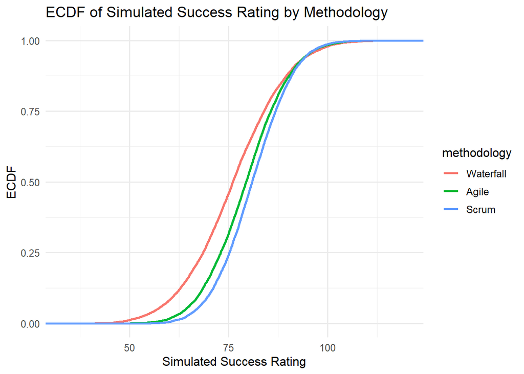

```r
p_ecdf <- ggplot(sim_all, aes(x = success_sim, color = methodology)) +
  stat_ecdf(linewidth = 1) +
  labs(title = "ECDF of Simulated Success Rating by Methodology",
       x = "Simulated Success Rating", y = "ECDF") +
  theme_minimal(base_size = 12)
p_ecdf
```

## **5.8. Tornado Chart - Spearman ρ**

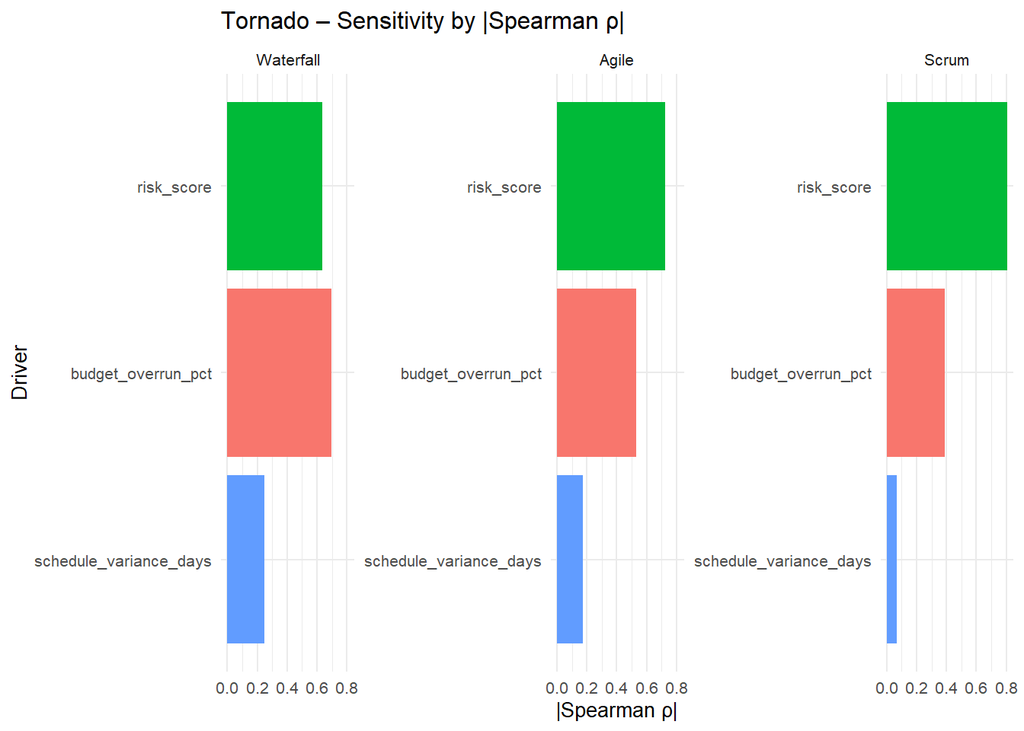

```r
sens_tbl <- sim_all %>%
  tidyr::pivot_longer(cols = all_of(drivers), names_to = "driver", values_to = "value") %>%
  dplyr::group_by(methodology, driver) %>%
  dplyr::summarise(rho = suppressWarnings(cor(value, success_sim, method = "spearman")),
                   .groups = "drop") %>%
  dplyr::mutate(rho_abs = abs(rho))

p_tornado <- ggplot(sens_tbl, aes(x = reorder(driver, rho_abs), y = rho_abs, fill = driver)) +
  geom_col() +
  coord_flip() +
  facet_wrap(~ methodology, scales = "free_y") +
  labs(title = "Tornado – Sensitivity by |Spearman ρ|",
       x = "Driver", y = "|Spearman ρ|") +
  theme_minimal(base_size = 10) +
  theme(legend.position = "none")
p_tornado
```

# 6. CONCLUSION

This study combined ART ANOVA, multiple regression, and Monte Carlo simulation to evaluate how project management methodology (Waterfall, Agile, Scrum), project complexity, and key execution drivers (risk, cost, schedule) jointly influence project success. Using a synthetic but structurally realistic dataset of 1,000 projects, the analysis first showed that, on the surface, methodology and complexity both matter: the ART ANOVA results indicated significant main effects for both methodology and complexity level on success_rating, but no significant interaction. This suggests that methodology and complexity each contribute to success in an additive way rather than in a way that depends on specific combinations (e.g., Scrum is effective only when applied on low-complexity projects).

The initial multiple regression model, which included only methodology and complexity, reinforced this message. With Waterfall and High complexity as baselines, Agile projects scored about 3.8 points higher on success_rating, and Scrum projects about 5.1 points higher; at the same time, Medium complexity projects scored roughly 8.3 points higher than High complexity, and Low complexity projects about 16.2 points higher. This model explained 43.8% of the variance in project success, and from this narrower view a portfolio manager might reasonably conclude that “Scrum and low-complexity projects are the safest bets” when the goal is to maximize success scores.

However, once the full set of operational drivers was included—risk_score, budget_overrun_pct, and schedule_variance_days—the picture changed substantially. In the full regression model, the adjusted R² increased to approximately 0.91, indicating that nearly all variance in success_rating could be explained by the combined effect of methodology, complexity, and these execution metrics. Crucially, the methodology coefficients for Agile and Scrum versus Waterfall became very small and statistically non-significant, and the effects of complexity level weakened to only marginal significance. In contrast, risk_score, budget_overrun_pct, and schedule_variance_days remained large, negative, and highly significant. This implies that, after controlling for risk exposure, cost overruns, and schedule delays, the nominal label “Waterfall,” “Agile,” or “Scrum” does not, by itself, drive project success. What matters most is how well the project is executed along these core dimensions.